# Advanced Clustering Analysis of Optical Recognition of Handwritten Digits Dataset

Dzaki

2026-06-05

# 1 LOAD LIBRARY

```r
library(tidyverse)
library(cluster)
library(factoextra)
library(corrplot)
library(caret)
library(gridExtra)
library(scales)
```

# 2 LOAD DATA

```r
train_url <- "https://archive.ics.uci.edu/ml/machine-learning-databases/optdigits/optdigits.tra"
test_url <- "https://archive.ics.uci.edu/ml/machine-learning-databases/optdigits/optdigits.tes"

train <- read.csv(train_url, header = FALSE)
test <- read.csv(test_url, header = FALSE)

digits <- rbind(train,test)

colnames(digits) <- c(
  paste0("Pixel_",1:64),
  "Digit"
)

dim(digits)
```

```
## [1] 5620   65
```

```r
head(digits)
```

```
##   Pixel_1 Pixel_2 Pixel_3 Pixel_4 Pixel_5 Pixel_6 Pixel_7 Pixel_8 Pixel_9
## 1       0       1       6      15      12       1       0       0       0
## 2       0       0      10      16       6       0       0       0       0
## 3       0       0       8      15      16      13       0       0       0
## 4       0       0       0       3      11      16       0       0       0
## 5       0       0       5      14       4       0       0       0       0
## 6       0       0      11      16      10       1       0       0       0
##   Pixel_10 Pixel_11 Pixel_12 Pixel_13 Pixel_14 Pixel_15 Pixel_16 Pixel_17
## 1        7       16        6        6       10        0        0        0
## 2        7       16        8       16        5        0        0        0
## 3        1       11        9       11       16        1        0        0
## 4        0        5       16       11       13        7        0        0
## 5        0       13        8        0        0        0        0        0
## 6        4       16       10       15        8        0        0        0
##   Pixel_18 Pixel_19 Pixel_20 Pixel_21 Pixel_22 Pixel_23 Pixel_24 Pixel_25
```

[output cut: 41 more lines]

## 2.1 DESKRIPSI DATASET

```r
summary(digits)
```

```
##     Pixel_1     Pixel_2          Pixel_3          Pixel_4         Pixel_5
##  Min.   :0   Min.   :0.0000   Min.   : 0.000   Min.   : 0.00   Min.   : 0.00
##  1st Qu.:0   1st Qu.:0.0000   1st Qu.: 1.000   1st Qu.:10.00   1st Qu.: 9.00
##  Median :0   Median :0.0000   Median : 5.000   Median :13.00   Median :13.00
##  Mean   :0   Mean   :0.3021   Mean   : 5.393   Mean   :11.82   Mean   :11.58
##  3rd Qu.:0   3rd Qu.:0.0000   3rd Qu.: 9.000   3rd Qu.:15.00   3rd Qu.:15.00
##  Max.   :0   Max.   :8.0000   Max.   :16.000   Max.   :16.00   Max.   :16.00
##     Pixel_6          Pixel_7          Pixel_8           Pixel_9
##  Min.   : 0.000   Min.   : 0.000   Min.   : 0.0000   Min.   :0.000000
##  1st Qu.: 0.000   1st Qu.: 0.000   1st Qu.: 0.0000   1st Qu.:0.000000
##  Median : 4.000   Median : 0.000   Median : 0.0000   Median :0.000000
##  Mean   : 5.594   Mean   : 1.379   Mean   : 0.1383   Mean   :0.003203
##  3rd Qu.:10.000   3rd Qu.: 0.000   3rd Qu.: 0.0000   3rd Qu.:0.000000
##  Max.   :16.000   Max.   :16.000   Max.   :16.0000   Max.   :5.000000
##     Pixel_10         Pixel_11        Pixel_12       Pixel_13
##  Min.   : 0.000   Min.   : 0.00   Min.   : 0.0   Min.   : 0.00
##  1st Qu.: 0.000   1st Qu.: 6.00   1st Qu.: 9.0   1st Qu.: 7.00
##  Median : 0.000   Median :12.00   Median :13.0   Median :11.00
##  Mean   : 1.971   Mean   :10.51   Mean   :11.8   Mean   :10.51
##  3rd Qu.: 3.000   3rd Qu.:15.00   3rd Qu.:15.0   3rd Qu.:15.00
##  Max.   :16.000   Max.   :16.00   Max.   :16.0   Max.   :16.00
##     Pixel_14         Pixel_15         Pixel_16          Pixel_17
##  Min.   : 0.000   Min.   : 0.000   Min.   : 0.0000   Min.   :0.00000
##  1st Qu.: 2.000   1st Qu.: 0.000   1st Qu.: 0.0000   1st Qu.:0.00000
##  Median : 9.000   Median : 0.000   Median : 0.0000   Median :0.00000
##  Mean   : 8.257   Mean   : 2.087   Mean   : 0.1379   Mean   :0.00427
##  3rd Qu.:14.000   3rd Qu.: 2.000   3rd Qu.: 0.0000   3rd Qu.:0.00000
##  Max.   :16.000   Max.   :16.000   Max.   :15.0000   Max.   :5.00000
##     Pixel_18         Pixel_19         Pixel_20         Pixel_21
##  Min.   : 0.000   Min.   : 0.000   Min.   : 0.000   Min.   : 0.000
##  1st Qu.: 0.000   1st Qu.: 4.000   1st Qu.: 1.000   1st Qu.: 1.000
##  Median : 1.000   Median :12.000   Median : 6.000   Median : 6.000
##  Mean   : 2.598   Mean   : 9.684   Mean   : 6.817   Mean   : 7.158
##  3rd Qu.: 4.000   3rd Qu.:15.000   3rd Qu.:12.000   3rd Qu.:13.000
##  Max.   :16.000   Max.   :16.000   Max.   :16.000   Max.   :16.000
##     Pixel_22         Pixel_23         Pixel_24          Pixel_25
##  Min.   : 0.000   Min.   : 0.000   Min.   :0.00000   Min.   :0.000000
##  1st Qu.: 0.000   1st Qu.: 0.000   1st Qu.:0.00000   1st Qu.:0.000000
##  Median : 9.000   Median : 0.000   Median :0.00000   Median :0.000000
##  Mean   : 7.971   Mean   : 1.964   Mean   :0.04947   Mean   :0.001068
```

[output cut: 57 more lines]

```
##  Max.   :16.000   Max.   :16.000   Max.   :13.0000   Max.   :1.0000000
##     Pixel_58          Pixel_59        Pixel_60        Pixel_61
##  Min.   : 0.0000   Min.   : 0.00   Min.   : 0.00   Min.   : 0.00
##  1st Qu.: 0.0000   1st Qu.: 1.00   1st Qu.:10.00   1st Qu.: 9.00
##  Median : 0.0000   Median : 5.00   Median :13.00   Median :13.00
##  Mean   : 0.2819   Mean   : 5.76   Mean   :11.99   Mean   :11.57
##  3rd Qu.: 0.0000   3rd Qu.:10.00   3rd Qu.:15.00   3rd Qu.:16.00
##  Max.   :10.0000   Max.   :16.00   Max.   :16.00   Max.   :16.00
##     Pixel_62         Pixel_63         Pixel_64           Digit
##  Min.   : 0.000   Min.   : 0.000   Min.   : 0.0000   Min.   :0.000
##  1st Qu.: 0.000   1st Qu.: 0.000   1st Qu.: 0.0000   1st Qu.:2.000
##  Median : 6.000   Median : 0.000   Median : 0.0000   Median :4.000
##  Mean   : 6.721   Mean   : 2.094   Mean   : 0.2541   Mean   :4.495
##  3rd Qu.:12.000   3rd Qu.: 2.000   3rd Qu.: 0.0000   3rd Qu.:7.000
##  Max.   :16.000   Max.   :16.000   Max.   :16.0000   Max.   :9.000
```

```r
table(digits$Digit)
```

```
##
##   0   1   2   3   4   5   6   7   8   9
## 554 571 557 572 568 558 558 566 554 562
```

Dataset terdiri dari 5620 observasi dengan 64 variabel prediktor dan satu variabel target berupa digit 0–9. Setiap fitur merepresentasikan intensitas piksel hasil ekstraksi citra tulisan tangan. Distribusi kelas relatif seimbang sehingga tidak terdapat indikasi class imbalance yang signifikan.

## 2.2 DISTRIBUSI LABEL

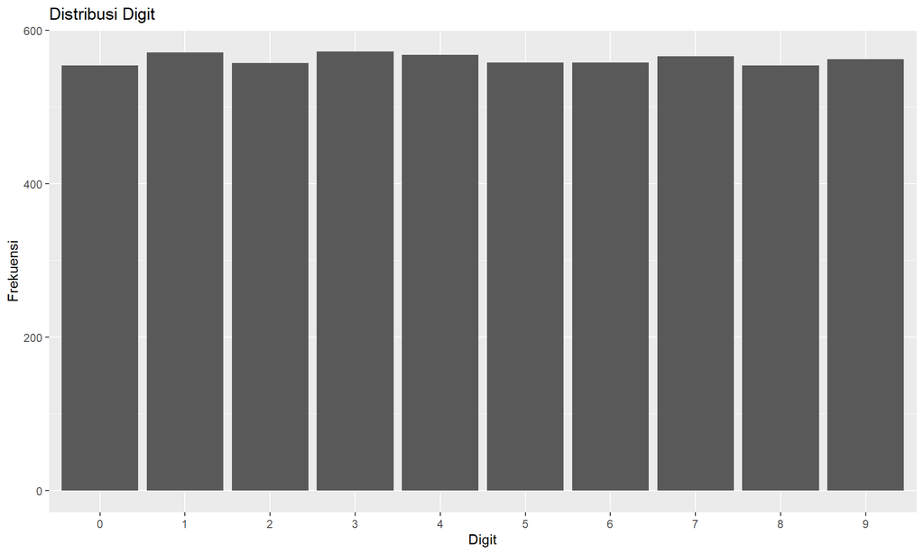

```r
ggplot(digits,
       aes(x=factor(Digit)))+
  geom_bar()+
  labs(
    title="Distribusi Digit",
    x="Digit",
    y="Frekuensi"
  )
```

Distribusi digit menunjukkan seluruh kelas memiliki jumlah observasi yang relatif proporsional. Kondisi ini mendukung evaluasi clustering karena setiap kelompok digit memiliki representasi yang memadai dalam dataset.

## 2.3 MISSING VALUE CHECK

```r
sum(is.na(digits))
```

```
## [1] 0
```

Tidak ditemukan missing value sehingga tidak diperlukan proses imputasi sebelum analisis clustering dilakukan.

# 3 PREPROCESSING

```r
X <- digits[,1:64]
y <- digits$Digit

# Hapus fitur dengan varians nol
zero_var <- apply(X, 2, var) == 0

X <- X[, !zero_var]

# Scaling
X_scaled <- scale(X)

dim(X_scaled)
```

```
## [1] 5620   62
```

Standardisasi dilakukan agar seluruh fitur memiliki rata-rata nol dan simpangan baku satu. Tahapan ini penting karena algoritma clustering berbasis jarak sangat sensitif terhadap perbedaan skala variabel.

# 4 PCA

```r
pca_model <- prcomp(
  X_scaled,
  center = FALSE,
  scale. = FALSE
)

summary(pca_model)
```

```
## Importance of components:
##                           PC1    PC2     PC3     PC4     PC5     PC6     PC7
## Standard deviation     2.6825 2.5111 2.19940 1.90261 1.73816 1.65975 1.54675
## Proportion of Variance 0.1161 0.1017 0.07802 0.05839 0.04873 0.04443 0.03859
## Cumulative Proportion  0.1161 0.2178 0.29578 0.35417 0.40290 0.44733 0.48592
##                            PC8     PC9    PC10   PC11    PC12    PC13    PC14
## Standard deviation     1.45123 1.32859 1.28520 1.2646 1.21892 1.19322 1.14014
## Proportion of Variance 0.03397 0.02847 0.02664 0.0258 0.02396 0.02296 0.02097
## Cumulative Proportion  0.51988 0.54836 0.57500 0.6008 0.62476 0.64772 0.66869
##                           PC15    PC16   PC17    PC18    PC19    PC20   PC21
## Standard deviation     1.10948 1.09273 1.0680 1.05380 0.99942 0.97609 0.9450
## Proportion of Variance 0.01985 0.01926 0.0184 0.01791 0.01611 0.01537 0.0144
## Cumulative Proportion  0.68854 0.70780 0.7262 0.74411 0.76022 0.77558 0.7900
##                           PC22    PC23    PC24    PC25    PC26    PC27    PC28
## Standard deviation     0.91533 0.88506 0.83973 0.79796 0.79275 0.78120 0.75700
## Proportion of Variance 0.01351 0.01263 0.01137 0.01027 0.01014 0.00984 0.00924
## Cumulative Proportion  0.80350 0.81613 0.82751 0.83778 0.84791 0.85776 0.86700
##                           PC29    PC30    PC31    PC32    PC33   PC34    PC35
## Standard deviation     0.73812 0.71466 0.70654 0.67309 0.66444 0.6252 0.61802
## Proportion of Variance 0.00879 0.00824 0.00805 0.00731 0.00712 0.0063 0.00616
## Cumulative Proportion  0.87579 0.88402 0.89208 0.89938 0.90650 0.9128 0.91897
##                           PC36    PC37    PC38    PC39    PC40    PC41    PC42
## Standard deviation     0.61173 0.58671 0.56415 0.55395 0.52962 0.52154 0.50456
## Proportion of Variance 0.00604 0.00555 0.00513 0.00495 0.00452 0.00439 0.00411
## Cumulative Proportion  0.92501 0.93056 0.93569 0.94064 0.94516 0.94955 0.95366
##                           PC43    PC44    PC45    PC46    PC47    PC48    PC49
## Standard deviation     0.49387 0.46650 0.46202 0.45038 0.44242 0.42236 0.40610
## Proportion of Variance 0.00393 0.00351 0.00344 0.00327 0.00316 0.00288 0.00266
## Cumulative Proportion  0.95759 0.96110 0.96454 0.96782 0.97097 0.97385 0.97651
##                          PC50   PC51    PC52    PC53    PC54   PC55    PC56
## Standard deviation     0.4018 0.3940 0.38733 0.37052 0.35793 0.3428 0.33858
## Proportion of Variance 0.0026 0.0025 0.00242 0.00221 0.00207 0.0019 0.00185
## Cumulative Proportion  0.9791 0.9816 0.98404 0.98625 0.98832 0.9902 0.99206
##                           PC57    PC58    PC59    PC60    PC61    PC62
## Standard deviation     0.32212 0.31283 0.29813 0.27974 0.25471 0.24180
## Proportion of Variance 0.00167 0.00158 0.00143 0.00126 0.00105 0.00094
## Cumulative Proportion  0.99374 0.99531 0.99675 0.99801 0.99906 1.00000
```